# Introduction to Social Networks with `netmem`

A 2-hour hands-on workshop

Alejandro Espinosa-Rada — Institute of Sociology, Pontificia Universidad Católica de Chile

23 June 2026

> **What this workshop is.** Two hours to go from *“a network is just dots and lines”* to *measuring* networks yourself, in R. We use [`netmem`](https://anespinosa.github.io/netmem/), a package that treats every network as a **matrix** and builds its measures on top of matrix algebra. If you can read a spreadsheet, you can read a network.

> **Who it is for.** People who are new to social networks but comfortable running basic R (assigning objects, calling functions, indexing a matrix).

> **How to use it.** Run every chunk yourself. Each section ends with a short *Your turn* exercise; click **Solution** to check your answer.

# 1 Setup

`netmem` is on CRAN, so installation is a one-liner. We also load `igraph` and `sna` — the two canonical network packages — for two reasons: to **draw** networks, and to show that the measures we compute with `netmem` match what the standard tools give. (`ggraph` is used for one polished plot near the end.)

```r
install.packages("netmem")   # the star of the show: measures from matrices
install.packages("igraph")   # canonical analysis + plotting
install.packages("sna")      # canonical analysis (works straight from matrices)
install.packages("ggraph")   # one nice ggplot-style network plot
```

```r
library(netmem)
library(igraph)
packageVersion("netmem")
```

```
#> [1] '1.0.3'
```

> **Two warnings about the canonical packages.**
> 1. `igraph` and `sna` define many functions with the *same name* (`degree`, `closeness`, …) that expect different inputs. To stay out of trouble we call them explicitly as `igraph::degree()` and `sna::degree()` rather than attaching `sna` with `library()`.
> 2. They speak different “native languages”: `igraph` wants a **graph object** (build it once with `graph_from_adjacency_matrix()`), while `sna` — like `netmem` — reads an **adjacency matrix directly**.

A tiny helper so our pictures look consistent throughout:

```r
plot_net <- function(M, mode = "directed", main = "", vcol = "#4C72B0") {
  g <- igraph::graph_from_adjacency_matrix(M, mode = mode, diag = FALSE)
  plot(g,
    main = main,
    vertex.color = vcol, vertex.frame.color = "white",
    vertex.size = 18, vertex.label.color = "black", vertex.label.cex = 0.8,
    edge.arrow.size = 0.4, edge.color = "grey60",
    layout = igraph::layout_with_fr
  )
}
```

# 2 Module 1 — A network *is* a matrix

A social network has two ingredients: **nodes** (people, organisations, papers) and **ties** between them (friendship, advice, citation). The most useful way to store that on a computer is the **adjacency matrix** `A`: one row and one column per node, and `A[i, j] = 1` when *i* sends a tie to *j*.

```r
A <- matrix(c(
  0, 1, 1, 0,
  0, 0, 1, 0,
  0, 0, 0, 1,
  1, 0, 0, 0
), byrow = TRUE, nrow = 4)
rownames(A) <- colnames(A) <- c("Ana", "Beto", "Cata", "Dani")
A
```

```
#>      Ana Beto Cata Dani
#> Ana    0    1    1    0
#> Beto   0    0    1    0
#> Cata   0    0    0    1
#> Dani   1    0    0    0
```

Read it as a sentence: *Ana points to Beto and Cata; Cata points to Dani; Dani points back to Ana.* Let’s see the same thing as a drawing:

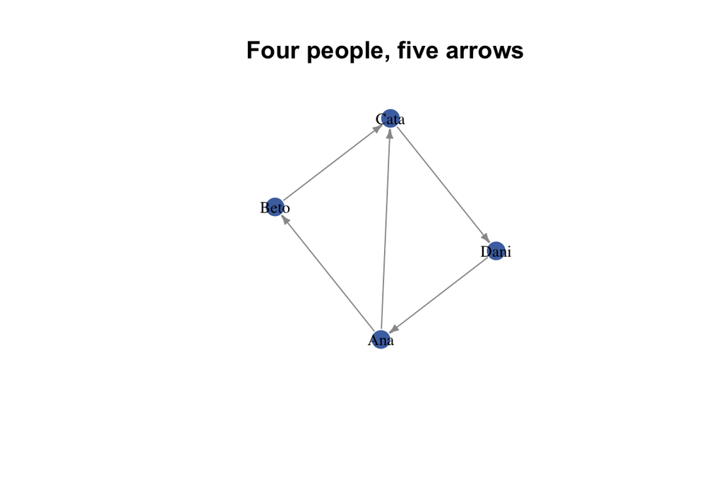

```r
plot_net(A, main = "Four people, five arrows")
```

`netmem` gives you a quick health-check of any matrix before you trust it — is it square? symmetric? binary? are there missing values or self-loops?

```r
matrix_report(A)
```

```
#> The matrix A might have the following characteristics:
#> --> The vectors of the matrix are `numeric`
#> --> Matrix is asymmetric (network is directed)
#> --> The matrix is square, 4 by 4
#>      nodes arcs
#> [1,]     4    5
```

## 2.1 Two ways to feed a network into R

Most real data does **not** arrive as a matrix. It arrives as an **edge list** (a two-column table: *who* → *whom*). `netmem` converts freely between the two, which is half the daily work of network analysis.

```r
# matrix  ->  edge list
E <- matrix_to_edgelist(A, digraph = TRUE)
E
```

```
#>      [,1]   [,2]
#> [1,] "Ana"  "Beto"
#> [2,] "Ana"  "Cata"
#> [3,] "Beto" "Cata"
#> [4,] "Cata" "Dani"
#> [5,] "Dani" "Ana"
```

```r
# edge list  ->  matrix (back where we started)
edgelist_to_matrix(E, digraph = TRUE)
```

[output not shown]

## 2.2 One-mode vs. two-mode

So far nodes were all the same kind (people->people): a **one-mode** network. Often the raw data instead links *two different kinds* of node — people to the events, committees, or papers they belong to. That is a **two-mode** (or *bipartite*) network, stored as an **incidence matrix**: rows are people, columns are groups.

```r
# 6 people (rows) by 4 committees (columns)
I <- matrix(c(
  1, 0, 0, 1,
  1, 1, 0, 0,
  0, 1, 1, 0,
  0, 1, 1, 0,
  0, 0, 1, 1,
  1, 0, 0, 1
), byrow = TRUE, nrow = 6)
rownames(I) <- paste0("person", 1:6)
colnames(I) <- paste0("comm", 1:4)
I
```

```
#>         comm1 comm2 comm3 comm4
#> person1     1     0     0     1
#> person2     1     1     0     0
#> person3     0     1     1     0
#> person4     0     1     1     0
#> person5     0     0     1     1
#> person6     1     0     0     1
```

We come back to two-mode networks in Module 6 — for now just notice that the *shape* of the matrix already tells you what kind of network you have.

> **Your turn 1.** Build the adjacency matrix of a 3-person *undirected* friendship triangle (everyone friends with everyone) and confirm with `matrix_report()` that it is symmetric.

**Solution**

```r
T3 <- matrix(c(
  0, 1, 1,
  1, 0, 1,
  1, 1, 0
), byrow = TRUE, nrow = 3)
matrix_report(T3)
```

```
#> The matrix A might have the following characteristics:
#> --> The vectors of the matrix are `numeric`
#> --> No names assigned to the rows of the matrix
#> --> No names assigned to the columns of the matrix
#> --> Matrix is symmetric (network is undirected)
#> --> The matrix is square, 3 by 3
#>      nodes edges
#> [1,]     3     3
```

# 3 Module 2 — Your first real network

Time for real data. `netmem` ships with **Krackhardt’s high-tech managers**: 21 managers in a firm, each reporting who they consider a **friend**. It is a classic teaching dataset.

```r
data(krackhardt_friends)
K <- krackhardt_friends
dim(K)                 # 21 managers x 21 managers
```

```
#> [1] 21 21
```

```r
K[1:6, 1:6]            # a corner of the matrix
```

```
#>      [,1] [,2] [,3] [,4] [,5] [,6]
#> [1,]    0    1    0    1    0    0
#> [2,]    1    0    0    0    0    0
#> [3,]    0    0    0    0    0    0
#> [4,]    1    1    0    0    0    0
#> [5,]    0    1    0    0    0    0
#> [6,]    0    1    0    0    0    0
```

Friendship here is **directed**: *I* may name *you* as a friend without you naming me. Let’s look at it:

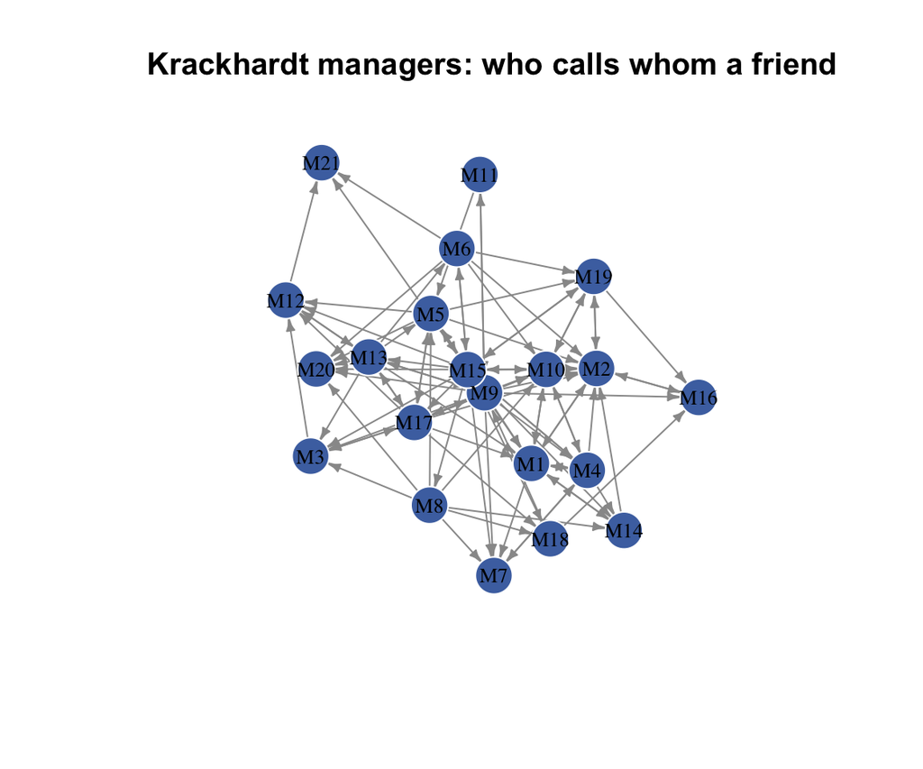

```r
rownames(K) <- colnames(K) <- paste0("M", 1:21)
plot_net(K, main = "Krackhardt managers: who calls whom a friend")
```

## 3.1 How dense, how reciprocated?

Two of the first questions in any study: *how many of the possible ties actually exist?* (**density**) and *when I name you, do you name me back?* (**reciprocity**).

```r
gen_density(K, directed = TRUE)              # share of possible ties present
```

```
#> [1] 0.2428571
```

```r
recip_coef(K, method = "global")             # share of ties that are returned
```

```
#> [1] 0.4509804
```

About a quarter of possible friendships exist, and roughly 45% of nominations are reciprocated — friendship is partly, but far from fully, mutual.

## 3.2 Who is central?

The simplest notion of importance is **degree**: how many ties a node has. Because the network is directed we separate **in-degree** (how many people name *you* — a measure of popularity) from **out-degree** (how many people *you* name). `gen_degree()` is `netmem`’s generalised degree, working for directed, weighted, and two-mode networks alike.

```r
indeg  <- gen_degree(K, type = "in")
outdeg <- gen_degree(K, type = "out")

# the four most-named (most popular) managers
sort(indeg, decreasing = TRUE)[1:4]
```

```
#>  M2  M1 M10  M5
#>  10   8   8   6
```

```r
# normalised in-degree: fraction of others who name you (Freeman, 1978)
round(sort(gen_degree(K, type = "in", normalized = TRUE), decreasing = TRUE)[1:5], 3)
```

```
#>  M2  M1 M10  M5  M9
#> 0.5 0.4 0.4 0.3 0.3
```

## 3.3 The same numbers, the canonical way

Whatever `netmem` reports, you should be able to reproduce with `igraph` or `sna`. This is worth doing once so you trust the tools — and so you can read code written in either ecosystem.

```r
# igraph needs a GRAPH object, built once from the matrix:
g <- igraph::graph_from_adjacency_matrix(K, mode = "directed", diag = FALSE)

# --- density ---
gen_density(K, directed = TRUE)   # netmem
```

```
#> [1] 0.2428571
```

```r
igraph::edge_density(g)           # igraph
```

```
#> [1] 0.2428571
```

```r
sna::gden(K)                      # sna: straight from the matrix (deals better with missing values!)
```

```
#> [1] 0.2428571
```

```r
# --- reciprocity ---
recip_coef(K, method = "global")  # netmem
```

```
#> [1] 0.4509804
```

```r
igraph::reciprocity(g)            # igraph
```

```
#> [1] 0.4509804
```

```r
recip_coef(K, method = "total_ratio")  # netmem
```

```
#>    Mutual
#> 0.7333333
```

```r
sna::grecip(K)                         # sna
```

```
#>       Mut
#> 0.7333333
```

```r
# --- in-degree (top 3 most popular) ---
sort(gen_degree(K, type = "in"), decreasing = TRUE)[1:3]          # netmem
```

```
#>  M2  M1 M10
#>  10   8   8
```

```r
sort(igraph::degree(g, mode = "in"), decreasing = TRUE)[1:3]      # igraph
```

```
#>  M2  M1 M10
#>  10   8   8
```

```r
sort(sna::degree(K, cmode = "indegree"), decreasing = TRUE)[1:3]  # sna
```

```
#> [1] 10  8  8
```

Three packages, identical answers. From here on we show the canonical equivalent for each new measure in a compact comment block.

> **Your turn 2.** Is anyone a “hub” who names many others but is named by few (high out-degree, low in-degree)? Compute `outdeg - indeg` and find the manager with the largest gap.

**Solution**

```r
gap <- outdeg - indeg
sort(gap, decreasing = TRUE)[1:3]   # names many, named by few
```

```
#> M15  M9  M8
#>  12   7   6
```

# 4 Interlude — Drawing networks

A good picture is the fastest way to *understand* a network before you measure it. Two things drive a readable plot: the **layout** (where nodes go) and the **aesthetics** (mapping size and colour to something meaningful). We let `netmem` do the measuring and `igraph`/`ggraph` do the drawing.

## 4.1 Layouts: same network, different stories

There is no single “correct” layout — each algorithm emphasises something different. Try a few and keep the one that communicates.

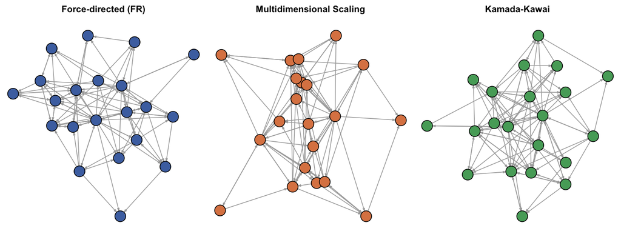

```r
op <- par(mfrow = c(1, 3), mar = c(0, 0, 2, 0))
plot(g, layout = igraph::layout_with_fr(g),     main = "Force-directed (FR)",
     vertex.size = 12, vertex.label = NA, edge.arrow.size = 0.2, vertex.color = "#4C72B0")
plot(g, layout = igraph::layout_with_mds(g),   main = "Multidimensional Scaling",
     vertex.size = 12, vertex.label = NA, edge.arrow.size = 0.2, vertex.color = "#DD8452")
plot(g, layout = igraph::layout_with_kk(g),     main = "Kamada-Kawai",
     vertex.size = 12, vertex.label = NA, edge.arrow.size = 0.2, vertex.color = "#55A868")
```

```r
par(op)
```

## 4.2 Aesthetics: let the measures drive the picture

The point of a network plot is to *show structure*. Here we size each node by its **in-degree** (popularity, from `gen_degree()`) and colour it by its **k-core** (how deep in the cohesive centre it sits, from `k_core()`). Now the picture and the numbers tell the same story.

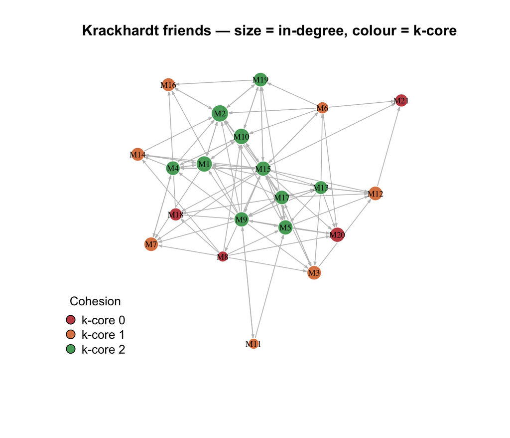

```r
KS    <- K * t(K)                            # mutual ties (used again in Module 3)
indeg <- gen_degree(K, type = "in")          # netmem: node importance
core  <- k_core(KS)                          # netmem: cohesion depth
pal   <- c("#C44E52", "#DD8452", "#55A868")  # colour per core level

plot(g,
  layout       = igraph::layout_with_fr(g),
  vertex.size  = 6 + 2.2 * sqrt(indeg),      # area ~ popularity
  vertex.color = pal[core + 1],
  vertex.frame.color = "white",
  vertex.label.cex = 0.7, vertex.label.color = "black",
  edge.arrow.size = 0.25, edge.color = "grey75",
  main = "Krackhardt friends — size = in-degree, colour = k-core"
)
legend("bottomleft", legend = paste("k-core", 0:2), pt.bg = pal,
       pch = 21, pt.cex = 1.6, bty = "n", title = "Cohesion")
```

## 4.3 A polished version with `ggraph`

`ggraph` brings the grammar of graphics to networks: edges and nodes become `geom_`s you can map aesthetics onto, exactly like `ggplot2`.

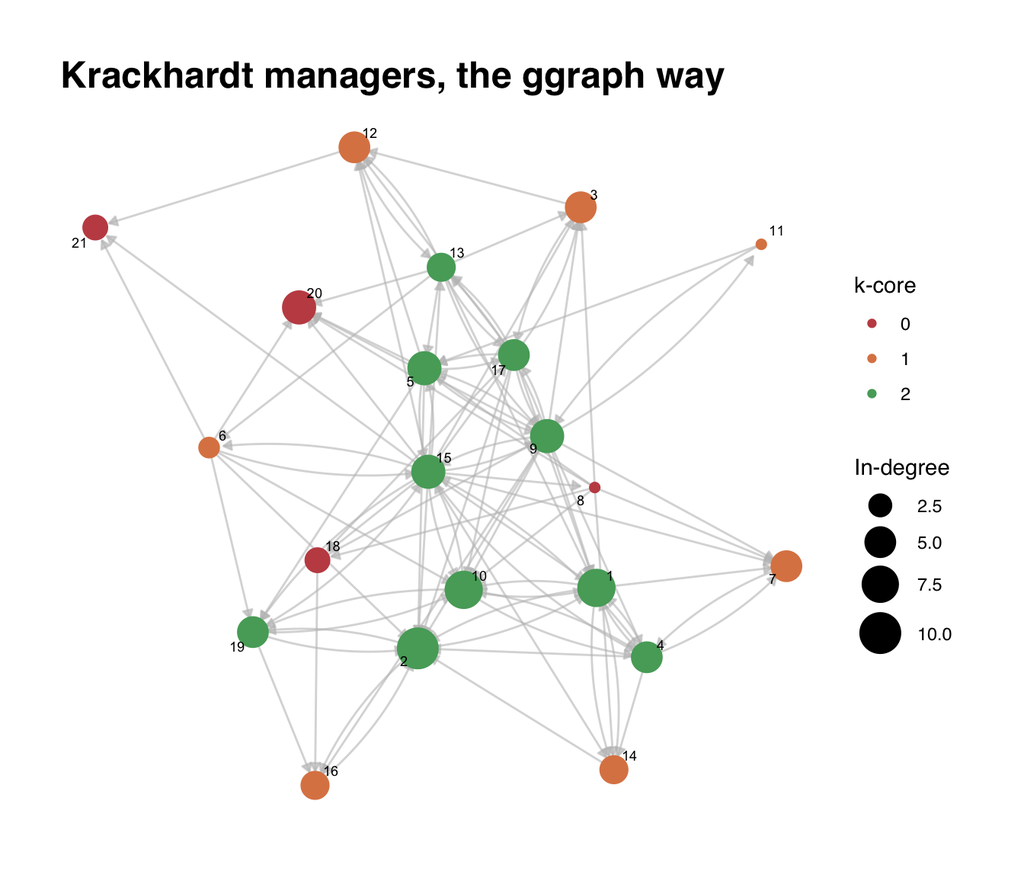

```r
library(ggraph)
library(ggplot2)

igraph::V(g)$indeg <- indeg
igraph::V(g)$core  <- factor(core)

ggraph(g, layout = "fr") +
  geom_edge_fan(arrow = arrow(length = unit(1.6, "mm"), type = "closed"),
                end_cap = circle(2.5, "mm"),
                edge_colour = "grey75", edge_alpha = 0.6) +
  geom_node_point(aes(size = indeg, colour = core)) +
  geom_node_text(aes(label = 1:vcount(g)), size = 2.4, repel = TRUE) +
  scale_size(range = c(2, 9)) +
  scale_colour_manual(values = pal) +
  labs(size = "In-degree", colour = "k-core",
       title = "Krackhardt managers, the ggraph way") +
  theme_graph(base_family = "sans")
```

# 5 Module 3 — Local structure: dyads, triangles, cores

Centrality is about single nodes. The sociological heart of network analysis is about **configurations** — the small patterns that repeat across the network and reveal how it is glued together.

## 5.1 The dyad census

Look at every **pair** of nodes. A pair is **mutual** (both name each other), **asymmetric** (one-way), or **null** (no tie). Counting all three is the *dyad census* — the simplest summary of a directed network’s texture.

```r
dyadic_census(K)
```

```
#>      Mutual Asymmetrics       Nulls
#>          23          56         131
```

```r
# canonical equivalents (same three counts):
igraph::dyad_census(g)   # g is the igraph object from Module 2
```

```
#> $mut
#> [1] 23
#>
#> $asym
#> [1] 56
#>
#> $null
#> [1] 131
```

```r
sna::dyad.census(K)
```

```
#>      Mut Asym Null
#> [1,]  23   56  131
```

## 5.2 Transitivity: are my friends friends with each other?

*“A friend of my friend is my friend.”* When that closure happens a lot, the network is **transitive** and full of triangles — the signature of tight social worlds. We work with the **mutual** (undirected) friendships here.

```r
KS <- K * t(K)                       # keep only reciprocated ties -> undirected
trans_coef(KS, method = "global")    # global clustering coefficient
```

```
#> [1] 0.295082
```

```r
gKS <- igraph::graph_from_adjacency_matrix(KS, mode = "undirected", diag = FALSE)
igraph::transitivity(gKS, type = "global")   # canonical equivalent
```

```
#> [1] 0.295082
```

```r
sna::gtrans(K)                           # weak census as clustering coefficient
```

```
#> [1] 0.4610526
```

```r
trans_coef(K, method = c("weakcensus"))  # weak census as clustering coefficient
```

```
#> [1] 0.4610526
```

## 5.3 Cores and components

- **Components** are the disconnected islands of the network.
- The **k-core** peels the network like an onion: the *k*-core is the part where everyone still has at least *k* connections. High cores are dense, cohesive centres.

`components_id()` returns a list: a `$components` membership vector and a `$size` table. The number of islands is the number of entries in `$size`.

```r
comp <- components_id(KS)
length(comp$size)                    # how many islands (4 isolates + 1 big core)
```

```
#> [1] 5
```

```r
table(k_core(KS))                    # how many nodes sit in each core level
```

```
#>
#>  0  1  2
#>  4  7 10
```

```r
igraph::components(gKS)$no            # number of components, canonical
```

```
#> [1] 5
```

```r
table(igraph::coreness(gKS))         # coreness == k-core membership
```

```
#>
#>  0  1  2
#>  4  7 10
```

## 5.4 Cliques

A **clique** is a fully connected group — everyone tied to everyone. The smallest interesting one is the triangle (3-clique).

```r
rownames(KS) <- 1:NROW(KS); colnames(KS) <- rownames(KS)
cl <- clique_table(KS, number = TRUE)
cl$table                             # the cliques themselves
```

```
#>       node triad300
#>  [1,] "1"  "3"
#>  [2,] "4"  "3"
#>  [3,] "4"  "2"
#>  [4,] "5"  "5"
#>  [5,] "5"  "6"
#>  [6,] "9"  "5"
#>  [7,] "9"  "6"
#>  [8,] "9"  "4"
#>  [9,] "10" "3"
#> [10,] "10" "2"
#> [11,] "10" "1"
#> [12,] "13" "4"
#> [13,] "15" "2"
#> [14,] "15" "5"
#> [15,] "15" "1"
#> [16,] "17" "6"
#> [17,] "17" "4"
#> [18,] "19" "1"
```

```r
cl$n_triangles                       # number of triangles in the mutual network
```

```
#> [1] 6
```

```r
dc <- dyadic_census(K)
unname(dc["Mutual"] / (dc["Mutual"] + dc["Asymmetrics"]))
```

```
#> [1] 0.2911392
```

# 6 Module 4 — Ego networks & structural holes

Zoom in on one person — **ego** — and the people they are tied to — their **alters**. The shape of that little neighbourhood predicts real outcomes: Ronald Burt showed that people whose contacts *don’t know each other* sit on **structural holes** and tend to get the promotions and the good ideas.

We use a small, hand-built network so the geometry is visible. Node `g` is connected to everyone; the others are only loosely connected among themselves.

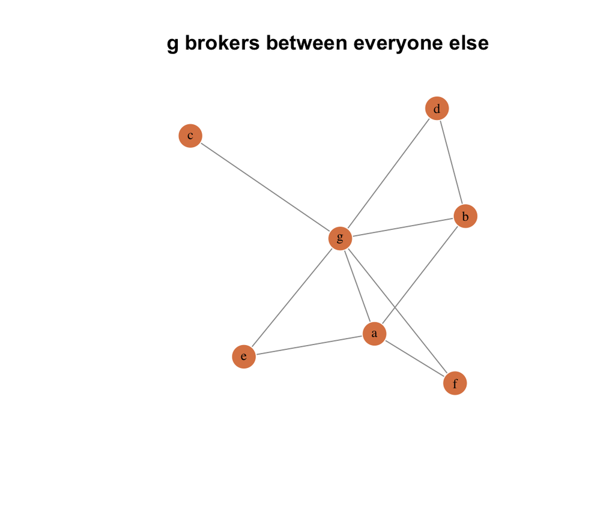

```r
A <- matrix(c(
  0, 1, 0, 0, 1, 1, 1,
  1, 0, 0, 1, 0, 0, 1,
  0, 0, 0, 0, 0, 0, 1,
  0, 1, 0, 0, 0, 0, 1,
  1, 0, 0, 0, 0, 0, 1,
  1, 0, 0, 0, 0, 0, 1,
  1, 1, 1, 1, 1, 1, 0
), ncol = 7, byrow = TRUE)
rownames(A) <- colnames(A) <- letters[1:7]
plot_net(A, mode = "undirected", main = "g brokers between everyone else", vcol = "#DD8452")
```

Extract `g`’s personal network — just ego’s neighbours and the ties among them:

```r
ego_net(A, ego = "g")
```

```
#>   a b c d e f
#> a 0 1 0 0 1 1
#> b 1 0 0 1 0 0
#> c 0 0 0 0 0 0
#> d 0 1 0 0 0 0
#> e 1 0 0 0 0 0
#> f 1 0 0 0 0 0
```

## 6.1 Redundancy and effective size

If your contacts all know each other, they give you **redundant** information. Burt’s **effective size** discounts that redundancy; **efficiency** scales it by how many contacts you have.

```r
redundancy(A, ego = "g")
```

```
#> $redundancy
#> [1] 1.333333
#>
#> $effective_size
#> [1] 4.666667
#>
#> $efficiency
#> [1] 0.7777778
```

## 6.2 Constraint

**Constraint** is high when you are stuck inside a tight, closed group with few independent options — the opposite of brokerage. `eb_constraint()` implements the Everett–Borgatti formulation of Burt’s measure.

```r
eb_constraint(A, ego = "g")   # the broker, tied to everyone
```

```
#> $results
#>   term1 term2 term3 constraint normalization
#> g 0.167 0.162 0.072        0.4         0.594
#>
#> $maximum
#>    g
#> 0.56
```

```r
eb_constraint(A, ego = "b")   # an ordinary node tied to a, d, g
```

```
#> $results
#>   term1 term2 term3 constraint normalization
#> b 0.333  0.37 0.136       0.84         0.854
#>
#> $maximum
#>     b
#> 0.926
```

> **Your turn 4.** Whose position is more constrained — `a` or `g`? Compute the constraint for both and explain the result in one sentence.

**Solution**

```r
eb_constraint(A, ego = "a")$results
```

|  | term1 | term2 | term3 | constraint | normalization |
| --- | --- | --- | --- | --- | --- |
| a | 0.25 | 0.281 | 0.152 | 0.684 | 0.841 |

```r
eb_constraint(A, ego = "g")$results
```

|  | term1 | term2 | term3 | constraint | normalization |
| --- | --- | --- | --- | --- | --- |
| g | 0.167 | 0.162 | 0.072 | 0.4 | 0.594 |

```r
# g brokers between otherwise-disconnected alters, so g is far less constrained.
```

# 7 Module 5 — Homophily: do birds of a feather flock?

People tend to befriend others *like themselves* — same gender, office, or profession. That tendency is **homophily**, and it is one of the most robust findings in social science. `netmem` measures it directly from the matrix plus a node attribute.

We switch to **Lazega’s law firm**: 71 lawyers, with their friendship network and rich attributes (office, seniority, practice area…).

```r
data(lazega_lawfirm)
fr  <- lazega_lawfirm$friends           # 71 x 71 friendship matrix
att <- lazega_lawfirm$attributes        # attribute matrix (one column per variable)
colnames(att)
```

```
#> [1] "seniority"  "status"     "gender"     "office"     "years"
#> [6] "age"        "practice"   "law_school"
```

Give the matrix labels and keep mutual friendships:

```r
rownames(fr) <- colnames(fr) <- paste0("L", 1:nrow(fr))
frS    <- fr * t(fr)                     # reciprocated friendships
office <- att[, "office"]                # 1 = Boston, 2 = Hartford, 3 = Providence
```

## 7.1 The mixing matrix

The **mixing matrix** cross-tabulates ties by the groups of the two people involved. Big numbers on the **diagonal** mean people befriend within their own group — the fingerprint of homophily.

```r
mix_matrix(frS, att = office)
```

```
#>     To
#> From   1   2   3
#>    1 124  18   2
#>    2  18  32   0
#>    3   2   0   0
```

## 7.2 One number: the E–I index

Krackhardt & Stern’s **E–I index** boils homophily down to a single number between −1 and +1:

- **−1** = every tie is *internal* (perfect homophily),
- **+1** = every tie is *external* (perfect heterophily),
- **0** = ties ignore the attribute.

```r
ei_index(frS, mixed = FALSE, att = office)                 # by office
```

```
#> [1] -0.5918367
```

```r
ei_index(frS, mixed = FALSE, att = att[, "practice"])      # by practice area
```

```
#> [1] 0.1147541
```

Office produces strong homophily (a large negative value); practice area far less so.

The canonical counterpart in `igraph` is the **assortativity coefficient**. Watch the **sign convention**: assortativity runs the *opposite* way to the E–I index — homophily is **positive** for assortativity but **negative** for E–I.

```r
gfr <- igraph::graph_from_adjacency_matrix(frS, mode = "undirected", diag = FALSE)
igraph::assortativity_nominal(gfr, as.integer(factor(office)))   # +0.69: strong homophily
```

```
#> [1] 0.6895396
```

Both agree the firm is strongly segregated by office — they just label it with opposite signs.

## 7.3 How diverse is the firm to begin with?

Homophily is only meaningful against the available diversity. **Blau’s index** (and its normalised cousin, the IQV) measures how spread out a categorical attribute is — 0 means everyone is identical, higher means more varied.

```r
heterogeneity(office, normalized = TRUE)
```

```
#> $blau
#>         1
#> 0.4681611
#>
#> $iqv
#>         1
#> 0.7022416
```

> **Your turn 5.** Compute the E–I index for **gender** (`att[, "gender"]`). Are friendships more segregated by gender or by office?

**Solution**

```r
ei_index(frS, mixed = FALSE, att = att[, "gender"])
```

```
#> [1] -0.07423581
```

```r
# Compare to the office value above: office segregates friendship far more strongly.
```

# 8 Module 6 — Beyond the simple graph

This is where `netmem`’s matrix philosophy pays off. The same algebra extends to networks that classic tools handle awkwardly: **two-mode**, **signed**, and **multilevel**.

## 8.1 Two-mode networks and their projections

Recall the people-by-committees incidence matrix from Module 1. We can **project** it into two one-mode networks: people linked by *shared committees*, and committees linked by *shared members*.

```r
proj <- matrix_projection(I)
proj$matrix1     # committees connected by shared members (overlap counts)
```

```
#>       comm1 comm2 comm3 comm4
#> comm1     3     1     0     2
#> comm2     1     3     2     0
#> comm3     0     2     3     1
#> comm4     2     0     1     3
```

```r
gen_density(I, bipartite = TRUE)                 # density of a two-mode network
```

[output not shown]

```r
gen_degree(I, bipartite = TRUE, type = "all")    # how many committees each person sits on
```

```
#> $bipartiteL1
#> person1 person2 person3 person4 person5 person6
#>       2       2       2       2       2       2
#>
#> $bipartiteL2
#> comm1 comm2 comm3 comm4
#>     3     3     3     3
```

## 8.2 Signed networks: friends *and* enemies

Real relationships are not only present/absent — they can be **positive (+1)** or **negative (−1)**. **Structural balance** theory (Heider) says the stable configurations are *“the enemy of my enemy is my friend.”* `struc_balance()` checks how balanced a signed network is.

```r
S <- matrix(c(
   0,  1, -1,
   1,  0, -1,
  -1, -1,  0
), byrow = TRUE, nrow = 3)
rownames(S) <- colnames(S) <- c("a", "b", "c")
struc_balance(S)                                 # a & b are friends, both dislike c
```

```
#> $table
#>   sign1 sign2 sign3 number balance
#> 1    -1    -1     1      3     --+
#>
#> $balance_score
#> [1] 1
```

A `balance_score` of 1 means this triangle is perfectly balanced: two friends united against a common adversary.

## 8.3 Multilevel networks

Sometimes nodes live at **different levels** — say individuals *and* the organisations they belong to — with ties within and between levels. `netmem` stacks the pieces into one **meta-matrix** and computes degree across the whole structure.

```r
A1 <- matrix(c(                # level 1: ties among 5 individuals
  0, 1, 0, 0, 1,
  1, 0, 0, 1, 1,
  0, 0, 0, 1, 1,
  0, 1, 1, 0, 1,
  1, 1, 1, 1, 0
), byrow = TRUE, nrow = 5)

B1 <- matrix(c(                # affiliation: which of 3 groups each individual joins
  1, 0, 0,
  1, 1, 0,
  0, 1, 0,
  0, 1, 0,
  0, 1, 1
), byrow = TRUE, nrow = 5)

A2 <- matrix(c(                # level 2: ties among the 3 groups
  0, 1, 1,
  1, 0, 0,
  1, 0, 0
), byrow = TRUE, nrow = 3)

# the full multilevel system as a single matrix
meta_matrix(A1, B1, A2 = A2)
```

```
#>      [,1] [,2] [,3] [,4] [,5] [,6] [,7] [,8]
#> [1,]    0    1    0    0    1    1    0    0
#> [2,]    1    0    0    1    1    1    1    0
#> [3,]    0    0    0    1    1    0    1    0
#> [4,]    0    1    1    0    1    0    1    0
#> [5,]    1    1    1    1    0    0    1    1
#> [6,]    1    1    0    0    0    0    1    1
#> [7,]    0    1    1    1    1    1    0    0
#> [8,]    0    0    0    0    1    1    0    0
```

```r
# degree that counts ties to BOTH peers and groups
multilevel_degree(A1, B1, A2 = A2)
```

|  | multilevel |
| --- | --- |
| n1 | 3 |
| n2 | 5 |
| n3 | 3 |
| n4 | 4 |
| n5 | 6 |
| m1 | 4 |
| m2 | 5 |
| m3 | 2 |

> **Your turn 6.** In the two-mode `I` data, use `matrix_projection(I)$matrix2` to get the *people* projection. Which two people share the most committees?

**Solution**

```r
people <- matrix_projection(I)$matrix2
diag(people) <- 0
which(people == max(people), arr.ind = TRUE)   # the most-overlapping pair(s)
```

```
#>         row col
#> person6   6   1
#> person4   4   3
#> person3   3   4
#> person1   1   6
```

# 9 Wrap-up

In two hours you went from *“a network is dots and lines”* to:

- storing a network as a **matrix** and converting to/from edge lists (`matrix_report`, `matrix_to_edgelist`, `edgelist_to_matrix`);
- describing it — **density, degree, reciprocity, transitivity, cores, cliques** (`gen_density`, `gen_degree`, `recip_coef`, `trans_coef`, `k_core`, `clique_table`, `dyadic_census`);
- zooming into **ego networks and structural holes** (`ego_net`, `redundancy`, `eb_constraint`);
- measuring **homophily** (`mix_matrix`, `ei_index`, `heterogeneity`);
- and stepping **beyond the simple graph** to two-mode, signed, and multilevel networks (`matrix_projection`, `struc_balance`, `meta_matrix`, `multilevel_degree`).

Along the way you saw every measure **reproduced in `igraph` and `sna`** — so you can trust the numbers and read code from any ecosystem — and learned to **draw** networks (layouts + aesthetics in `igraph` and `ggraph`) so the picture and the measures tell one story.

The thread running through all of it: **once your network is a matrix, every measure is just algebra you can read, check, and trust.**

## 9.1 A take-home challenge

The Lazega data also contains an **advice** network (`lazega_lawfirm$advice`) and a **cowork** network (`lazega_lawfirm$cowork`). Pick one and reproduce Modules 2–5 on it: Who is most sought for advice (in-degree)? Is advice-seeking reciprocated? Do lawyers ask advice within their own office (homophily)? Compare your answers to the friendship network.

## 9.2 Where to go next

- **Package site & full function reference:** https://anespinosa.github.io/netmem/
- **Source & issues:** https://github.com/anespinosa/netmem
- **More classic datasets:** the [`classicnets`](https://github.com/anespinosa/classicnets) package
- **Foundational reading:** Wasserman & Faust (1994), *Social Network Analysis: Methods and Applications*; Burt (1992), *Structural Holes*.

```r
citation("netmem")
```

```
#>
#>   Espinosa-Rada A (2026). _netmem: Social Network Measures using
#>   Matrices_. doi:10.32614/CRAN.package.netmem
#>   <https://doi.org/10.32614/CRAN.package.netmem>, R package version
#>   1.0-3, <https://CRAN.R-project.org/package=netmem>.
#>
#> A BibTeX entry for LaTeX users is
#>
#>   @Manual{,
#>     title = {netmem: Social Network Measures using Matrices},
#>     author = {Alejandro Espinosa-Rada},
#>     year = {2026},
#>     note = {R package version 1.0-3},
#>     url = {https://CRAN.R-project.org/package=netmem},
#>     doi = {10.32614/CRAN.package.netmem},
#>   }
```